# Canadian Air Pollutant Emmision Inventory by Jenny Lu

## Introduction

The Air Pollutant Emission Inventory (APEI) is an annual report of air pollutant emissions across Canada published by Environment and Climate Change Canada. The report details the release of air pollutants from all known of sources since 1990. The APEI serves many purposes, including:

- supporting the development of air quality management strategies, policies and regulations
- fulfilling Canada’s domestic and international reporting obligation
- informing Canadians about pollutants that affect their health and the environment
- providing data to support air quality forecasting.

- Criteria air contaminants (CACs):
  - Total particulate matter (TPM) with upper size limit of ~100 microns in aerodynamic equivalent diameter
  - Particulate matter less than or equal to 10 microns (PM10)
  - Particulate matter less than or equal to 2.5 microns (PM2.5)
  - Sulphur oxides (SOx)
  - Nitrogen oxides (NOx)
  - Volatile organic compounds (VOCs)
  - Carbon monoxide (CO)
  - Ammonia (NH3)
- Heavy metals:
  - Mercury (Hg)
  - Lead (Pb)
- Cadmium (Cd) Persistent organic pollutants (POPs):
  - Dioxins and furans (D/F)
  - Four polycyclic aromatic hydrocarbons (PAHs) compounds (Benzo[a]pyrene, Benzo[b]fluoranthene, Benzo[k]fluoranthene and Indeno[1,2,3-cd]pyrene)
  - Hexachlorobenzene (HCB)

## Univariate Plots

Summary statistics for all 14 pollutants:

```
##       TPM               PM10             PM2.5             SOX
##  Min.   :      1   Min.   :      1   Min.   :     1   Min.   :      1
##  1st Qu.:     33   1st Qu.:     23   1st Qu.:    15   1st Qu.:     21
##  Median :    256   Median :    161   Median :   107   Median :    194
##  Mean   :  53005   Mean   :  17874   Mean   :  4783   Mean   :  11959
##  3rd Qu.:   2393   3rd Qu.:   1233   3rd Qu.:   720   3rd Qu.:   1593
##  Max.   :9776264   Max.   :3086638   Max.   :654237   Max.   :1272085
##  NA's   :22497     NA's   :22759     NA's   :23057    NA's   :30621
##       NOX                VOC                CO               NH3
##  Min.   :     1.0   Min.   :      1   Min.   :      1   Min.   :     1
##  1st Qu.:    65.8   1st Qu.:     27   1st Qu.:     55   1st Qu.:     3
##  Median :   446.0   Median :    267   Median :    494   Median :    19
##  Mean   :  8588.2   Mean   :   9519   Mean   :  30914   Mean   :  3059
##  3rd Qu.:  3179.2   3rd Qu.:   2188   3rd Qu.:   4489   3rd Qu.:   130
##  Max.   :479120.0   Max.   :1601033   Max.   :4702127   Max.   :464604
##  NA's   :27805      NA's   :25378     NA's   :27716     NA's   :32594
##        Pb                 Cd                 Hg                D.F
##  Min.   :     0.1   Min.   :    0.10   Min.   :    0.10   Min.   :  0.00
##  1st Qu.:     1.8   1st Qu.:    0.90   1st Qu.:    0.90   1st Qu.:  0.00
##  Median :    24.3   Median :    4.70   Median :    6.20   Median :  0.04
##  Mean   :  5304.6   Mean   :  444.48   Mean   :   96.28   Mean   :  1.06
##  3rd Qu.:   216.2   3rd Qu.:   31.62   3rd Qu.:   31.10   3rd Qu.:  0.37
##  Max.   :899202.9   Max.   :78289.80   Max.   :24903.80   Max.   :187.00
##  NA's   :39491      NA's   :41089      NA's   :35887      NA's   :39379
##       HCB                PAH
##  Min.   :    0.00   Min.   :     0.10
##  1st Qu.:    4.35   1st Qu.:     0.40
##  Median :   58.69   Median :     2.90
##  Mean   :  704.83   Mean   :  1403.08
##  3rd Qu.:  383.31   3rd Qu.:    29.02
##  Max.   :67996.70   Max.   :137076.40
##  NA's   :44950      NA's   :39593
```

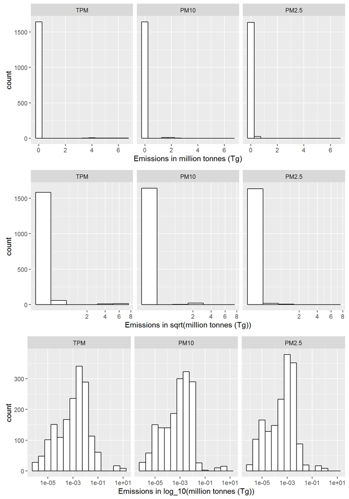

```
##       TPM               PM10             PM2.5
##  Min.   :      1   Min.   :      1   Min.   :     1
##  1st Qu.:    139   1st Qu.:     97   1st Qu.:    54
##  Median :   1761   Median :   1025   Median :   639
##  Mean   :  83060   Mean   :  31370   Mean   :  9223
##  3rd Qu.:   6571   3rd Qu.:   4055   3rd Qu.:  2059
##  Max.   :6538929   Max.   :2320670   Max.   :651155
##  NA's   :56        NA's   :56        NA's   :64
```

The histograms show the distribution of particulate matter pollution from all individual sources from 2009 to 2014 is not normal. Using a log_10 scale the distribution becomes slightly more normal although it is still quite skewed. Although, the distribution looks left-skewed, the summary statistics show that it is actually right-skewed (i.e. mean > median). The maximum is very high and far from both mean and median. Only later examination into sources and sectors can tell us if total pollution is being driven by a small number of large emissions (i.e. most emissions from a single source/sector) or, a large number of small emissions (i.e. emissions from many sources and sectors.

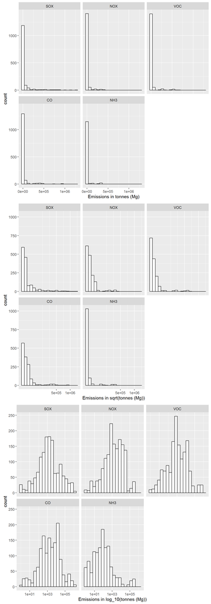

```
##       SOX                 NOX              VOC               CO
##  Min.   :      1.0   Min.   :     1   Min.   :     1   Min.   :     1.0
##  1st Qu.:    266.8   1st Qu.:   330   1st Qu.:   225   1st Qu.:   287.5
##  Median :   1306.0   Median :  1545   Median :   963   Median :  2060.0
##  Mean   :  34436.5   Mean   : 14635   Mean   : 18755   Mean   : 28832.7
##  3rd Qu.:   6293.0   3rd Qu.:  9207   3rd Qu.:  6895   3rd Qu.: 11463.5
##  Max.   :1271270.0   Max.   :394842   Max.   :644784   Max.   :925861.0
##  NA's   :341         NA's   :217      NA's   :224      NA's   :285
##       NH3
##  Min.   :     1
##  1st Qu.:    13
##  Median :    77
##  Mean   :  9385
##  3rd Qu.:   296
##  Max.   :364030
##  NA's   :528
```

The histograms show the distribution of the other CACs (SOx, NOx, VOC, CO, and NH3) from all individual sources from 2009 to 2014 is not normal. Using a log_10 scale the distribution becomes slightly more normal although it is still quite skewed. The summary statistics show the distribution is actually right-skewed (i.e. mean > median). Again, the maximum is very high and far from both mean and median. Almost all of the individual emissions quantities seem to be relatively small as almost all the data is contained within the first bin without any transformations.

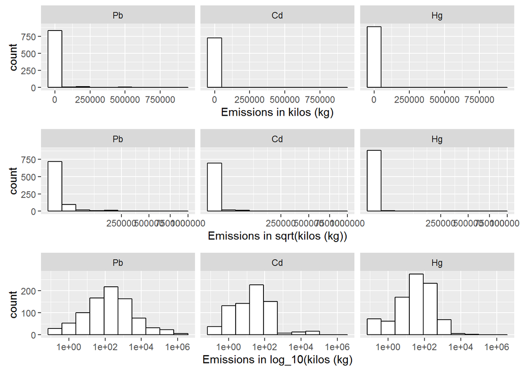

```
##        Pb                 Cd                 Hg
##  Min.   :     0.1   Min.   :    0.10   Min.   :    0.100
##  1st Qu.:    24.2   1st Qu.:    3.00   1st Qu.:    7.275
##  Median :   201.5   Median :   22.00   Median :   34.800
##  Mean   : 14565.9   Mean   : 1136.04   Mean   :  291.184
##  3rd Qu.:  1361.0   3rd Qu.:   86.85   3rd Qu.:  172.500
##  Max.   :897086.6   Max.   :78289.80   Max.   :24840.600
##  NA's   :859        NA's   :998        NA's   :837
```

The histograms show the distribution of heavy metal pollution pollution from all individual sources from 2009 to 2014 is not normal. Using a log_10 scale the distribution becomes slightly more normal although it is still quite skewed. The summary statistics show the distribution is actually right-skewed (i.e. mean > median). Again, the maximum is very high and far from both mean and median. Almost all of the individual emissions quantities seem to be relatively small as almost all the data is contained within the first bin without any transformations.

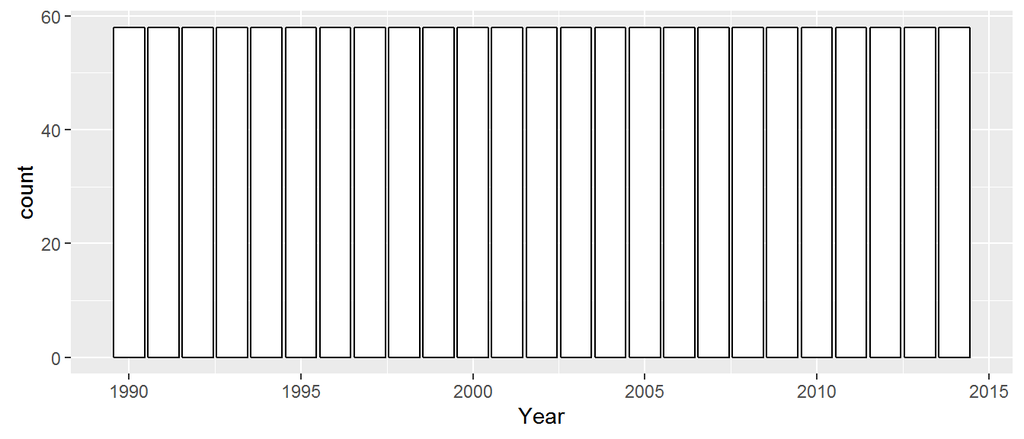

The variable year is discrete so a histogram would not make sense. A bar plot shows that there are equal counts of all years because same data is collected every year.

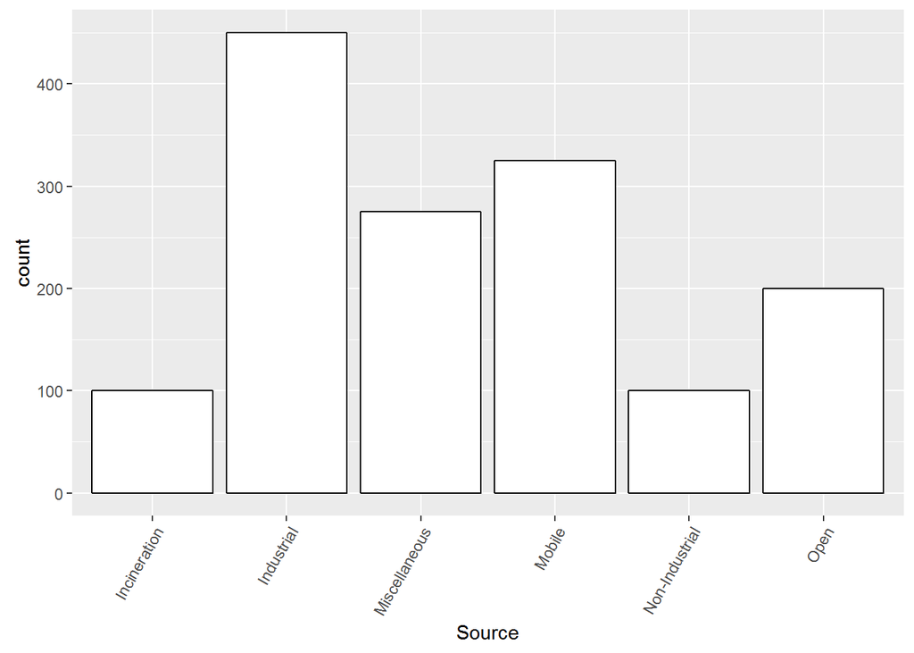

Source is also a discrete variable. There are different numbers of emission points from each type of source. We can see that there are the most number of industrial sources and least number of non-industrial and incineration sources. Mobile, miscellaneous, and open sources have the second, third, and fourth most number of emitters.

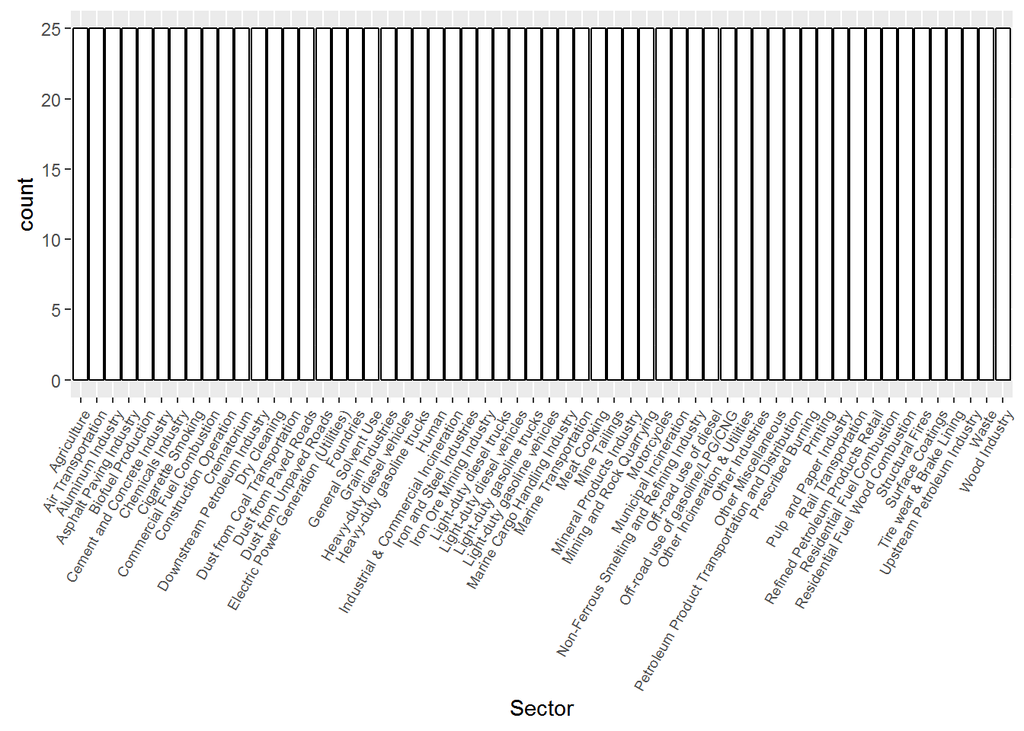

Sector is again, a discrete variable. The bar plot shows that there are equal counts for every sector because the every sector has emission data collected every year.

## Univariate Analysis

### What is the structure of your dataset?

There are 47625 observations of 19 variables. Variables in dataset:

```
##  [1] "Region"    "Year"      "Source"    "Sector"    "Subsector"
##  [6] "TPM"       "PM10"      "PM2.5"     "SOX"       "NOX"
## [11] "VOC"       "CO"        "NH3"       "Pb"        "Cd"
## [16] "Hg"        "D.F"       "HCB"       "PAH"
```

All sources:

```
## [1] "Incineration"           "Industrial"
## [3] "Industrial Sources"     "Miscellaneous"
## [5] "Mobile"                 "Non-Industrial"
## [7] "Non-Industrial Sources" "Open"
## [9] "Open Sources"
```

All sectors:

```
##  [1] "Agriculture"
##  [2] "Air Transportation"
##  [3] "Aluminum Industry"
##  [4] "Asphalt Paving Industry"
##  [5] "Biofuel Production"
##  [6] "Cement and Concrete Industry"
##  [7] "Chemicals Industry"
##  [8] "Cigarette Smoking"
##  [9] "Commercial Fuel Combustion"
## [10] "Construction Operation"
## [11] "Crematorium"
## [12] "Downstream Petroleum Industry"
## [13] "Dry Cleaning"
## [14] "Dust from Coal Transportation"
## [15] "Dust from Paved Roads"
```

[output cut: 43 more lines]

The APEI collects information about the following pollutants:

- Criteria air contaminants (CACs) i.e. smog precursors:
  - Total particulate matter (TPM) with upper size limit of ~100 microns in aerodynamic equivalent diameter
  - Particulate matter less than or equal to 10 microns (PM10)
  - Particulate matter less than or equal to 2.5 microns (PM2.5)
  - Sulphur oxides (SOx)
  - Nitrogen oxides (NOx)
  - Volatile organic compounds (VOCs)
  - Carbon monoxide (CO)
  - Ammonia (NH3)
- Heavy metals:
  - Mercury (Hg)
  - Lead (Pb)
  - Cadmium (Cd)
- Persistent organic pollutants (POPs):
  - Dioxins and furans (D/F)
  - Four polycyclic aromatic hydrocarbons (PAHs) compounds (Benzo[a]pyrene, Benzo[b]fluoranthene, Benzo[k]fluoranthene and Indeno[1,2,3-cd]pyrene)
  - Hexachlorobenzene (HCB)

### What are the main features of interest in your dataset?

The main features of interest are total emissions of each of the 14 pollutants within Canada. I would like to investigate trends - whether or not emissions have increased or decreased - and if they have increased, why?

### What other features in the dataset do you think will help support your investigation into your features of interest?

I will use the region, source, and sector features to further investigate the pollutants that have seen an increase in recent years.

### Did you create any new variables from existing variables in the dataset?

I did not create any new variables - save for the region variable which I added while combining all data in Python script.

### Did you perform any operations on the data to tidy, adjust, or change the form of the data? If so, why did you do this?

I did most of the data processing with Python prior to loading the data in R. I did subset the data to only look at Canada and all emission sources and sectors. I then aggregated the data by year to get the total emissions of a pollutant from all sources and sectors for a given year. I did this because there are simply too many data points to understand in a plot without using a summary statistic - such as sums.

# Bivariate Plots Section

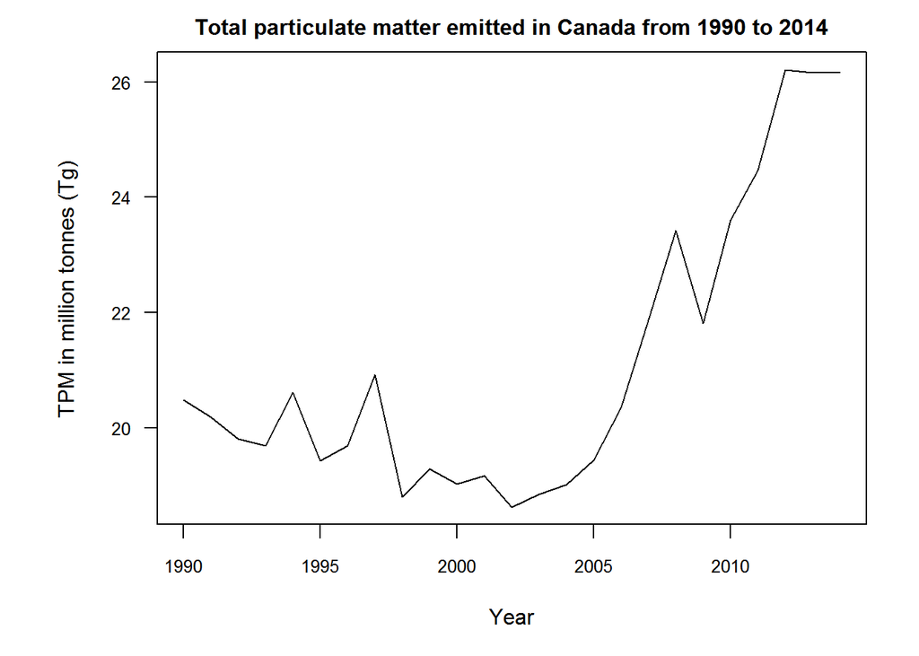

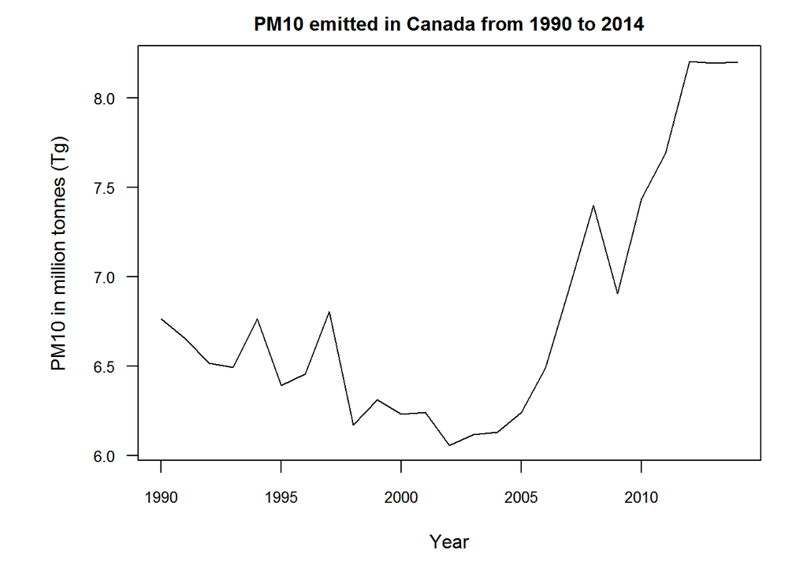

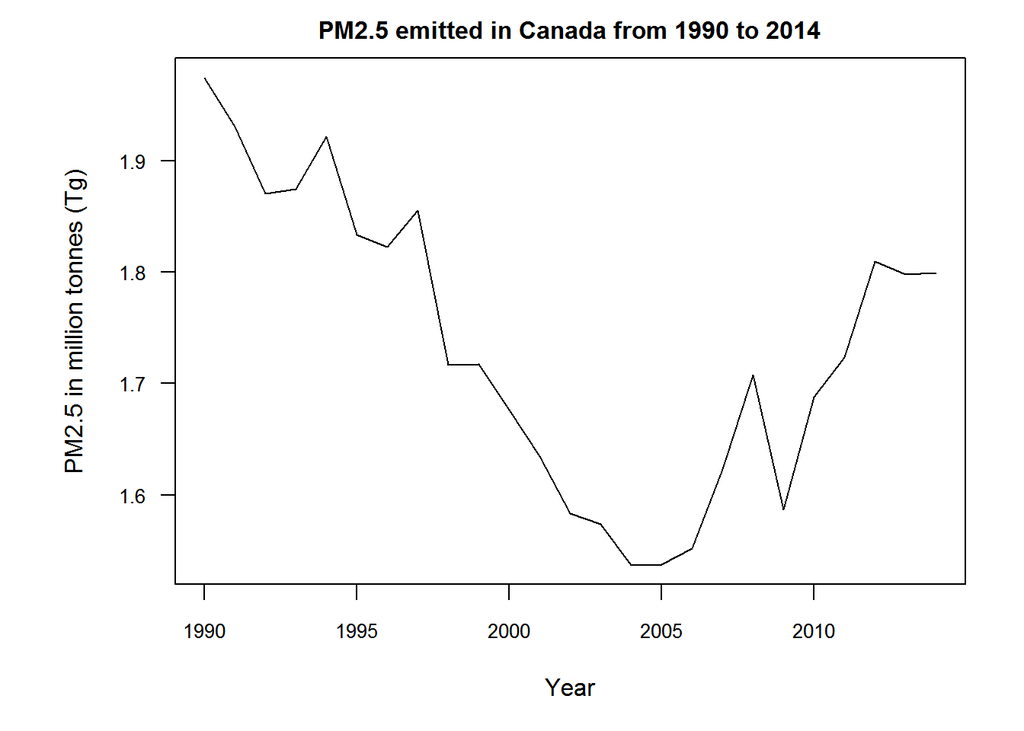

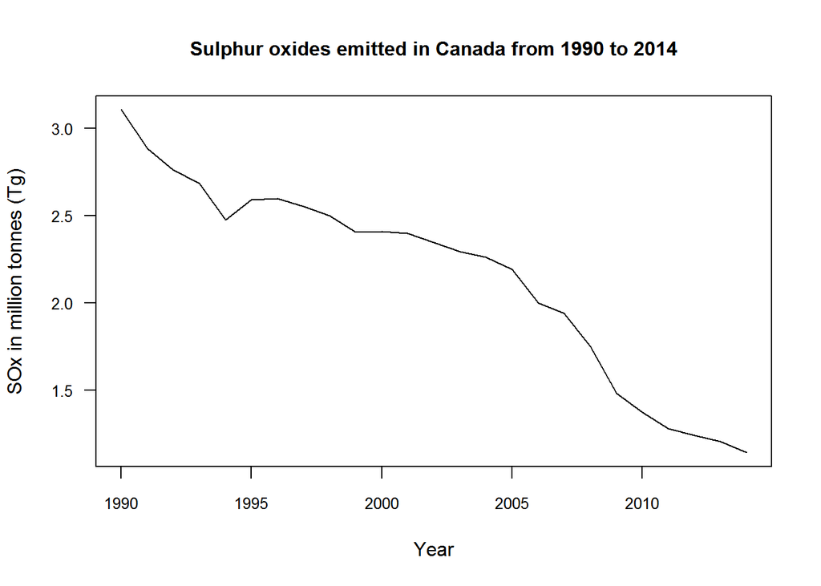

Overall SOx emissions decreased by 63% (2.0 Mt) between 1990 and 2014.

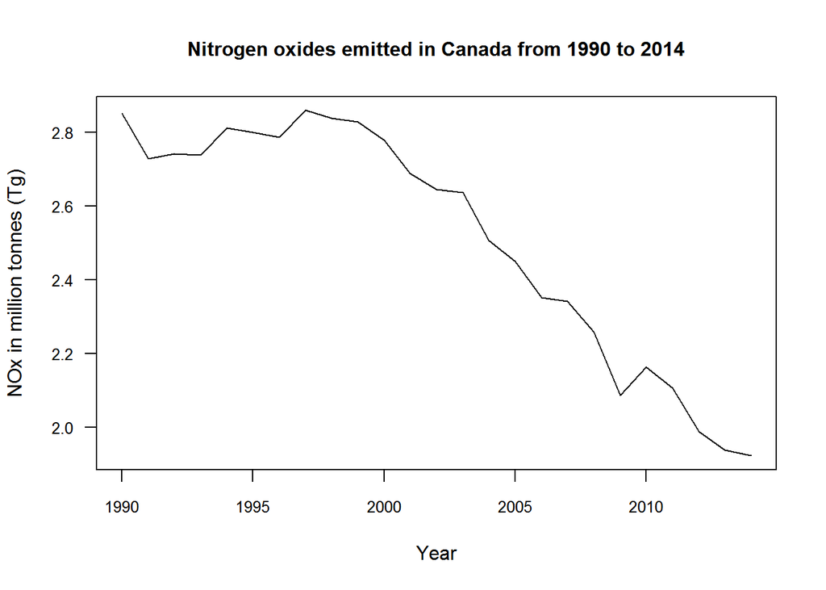

From 1990 to 2014, national NOx emissions decreased by 33% (900 kt).

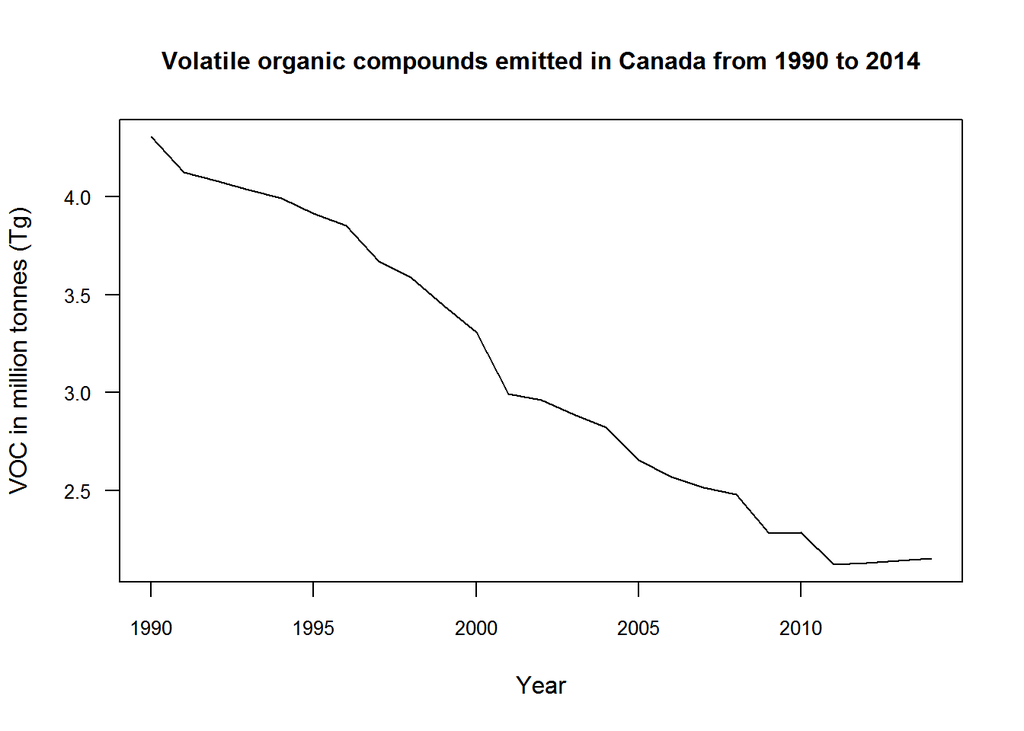

Between 1990 and 2014, VOC emissions decreased by 50% (2.1 Mt).

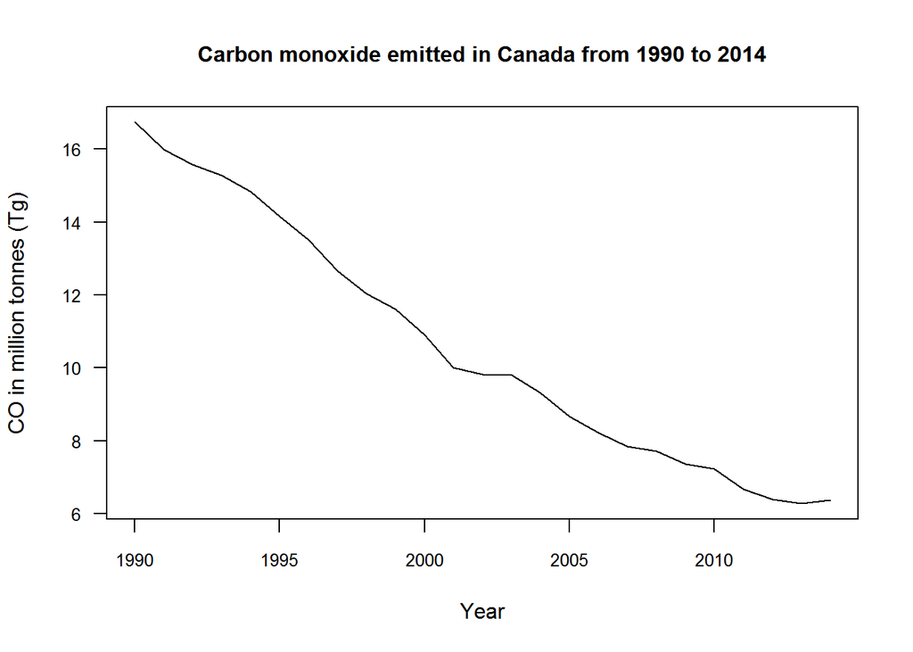

Between 1990 and 2014, CO emissions decreased by 62% (10 Mt).

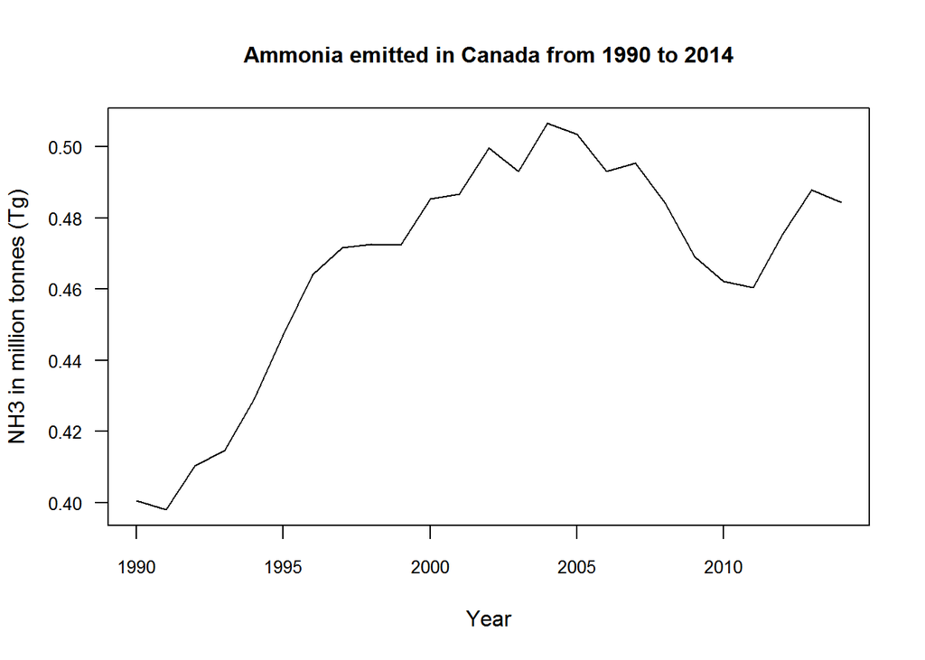

From 1990 to 2014, Canada’s NH3 emissions increased by 21% (84 kt).

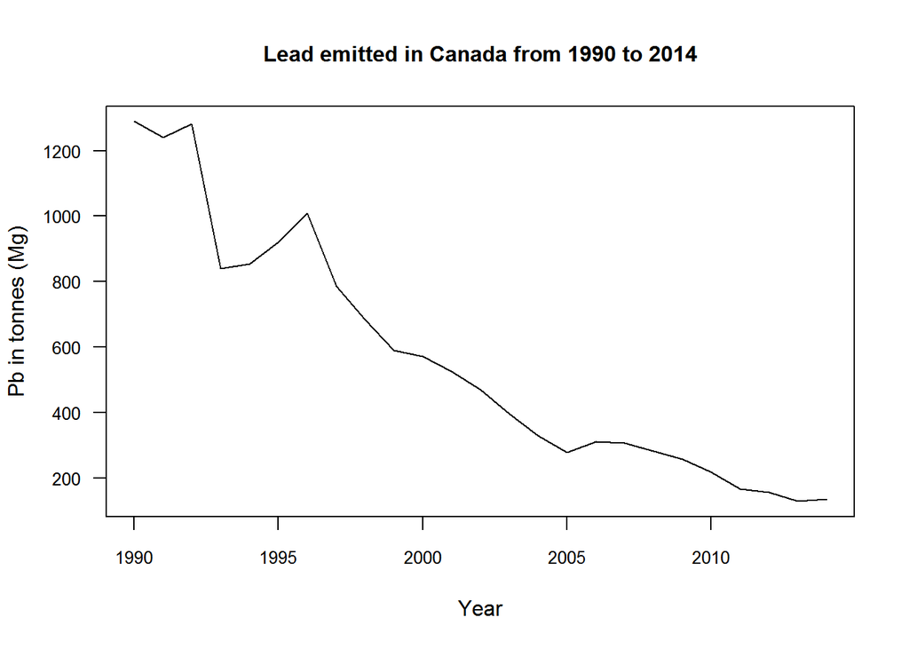

Pb emissions decreased by 89% (1.2 kt) from 1990 to 2014.

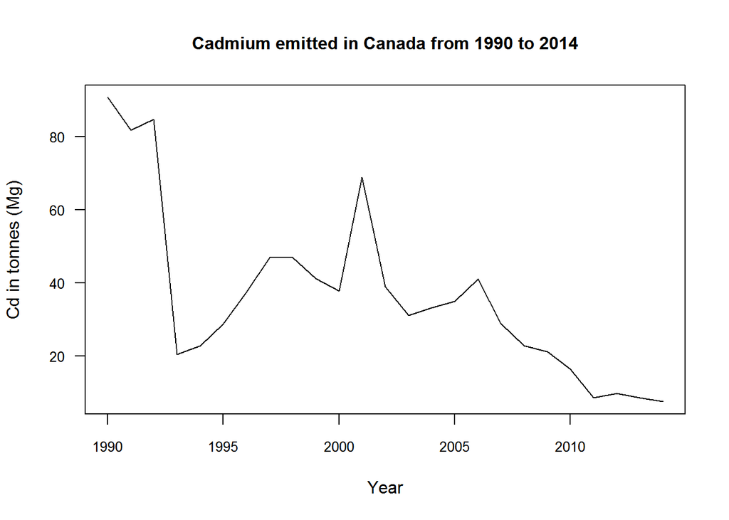

From 1990 to 2014, national Cd emissions decreased by 92% (83 t). There is an increase from 1993 to 2001 but the trend continues downward again after this.

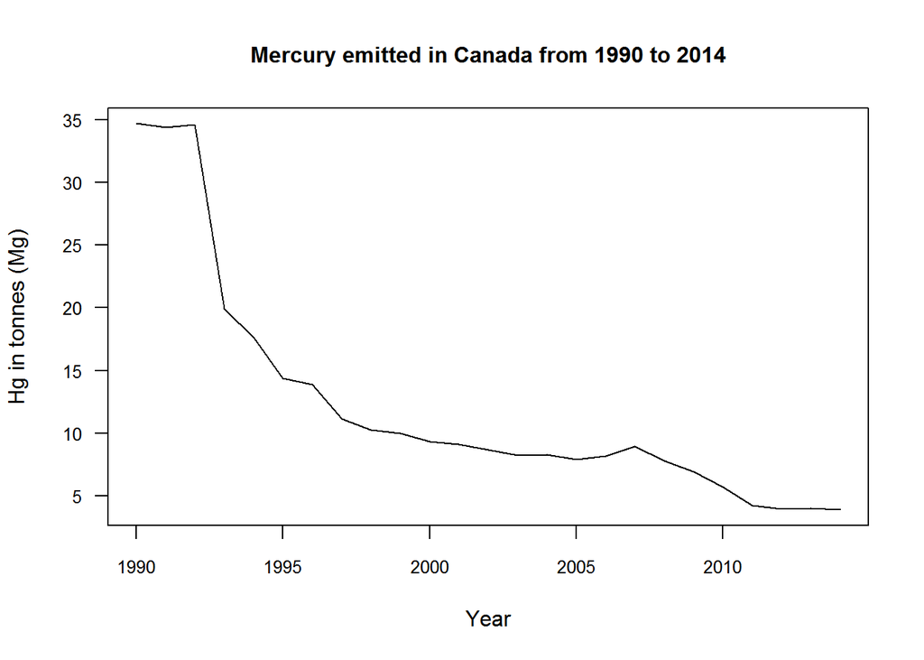

Between 1990 and 2014, Hg emissions decreased by 89% (31 t).

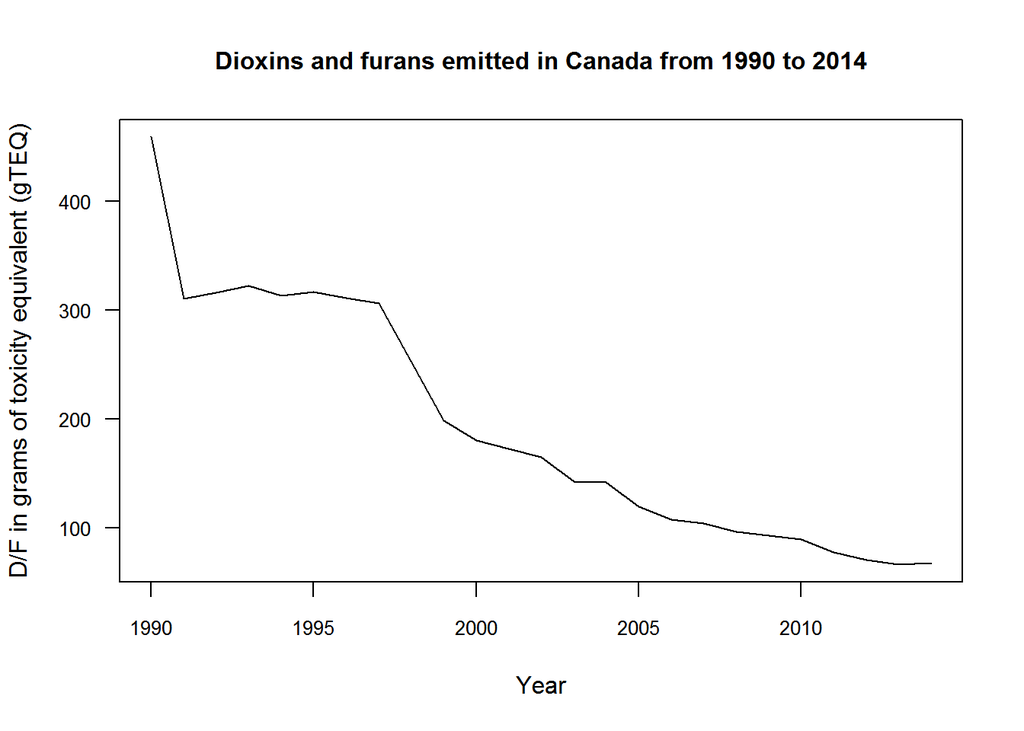

Between 1990 and 2014, D/F emissions decreased by 85% (390 gTEQ).

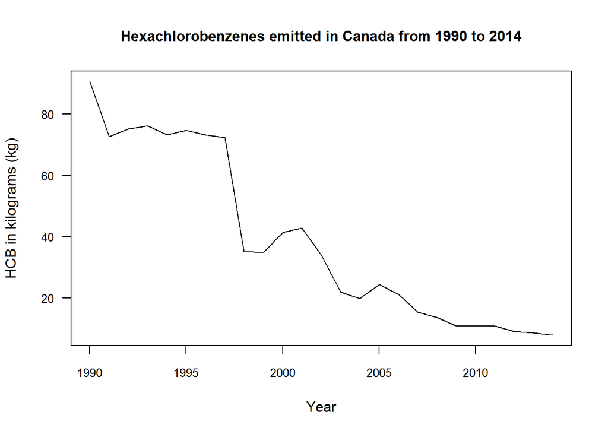

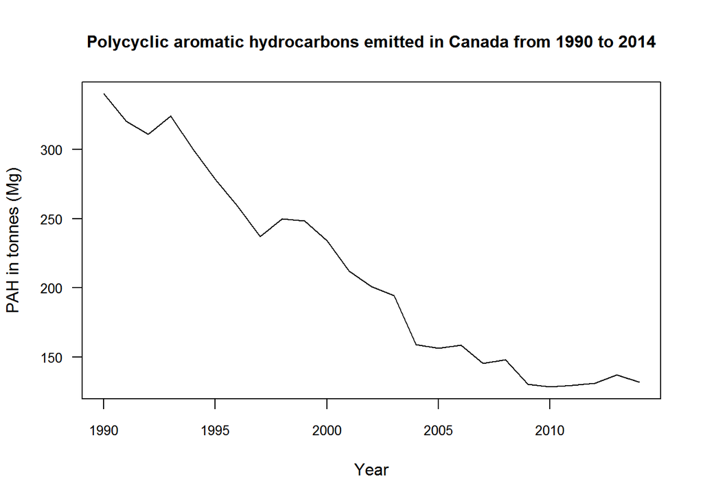

Overall, a 91% (83 kg) decrease in HCB emissions occurred between 1990 and 2014.

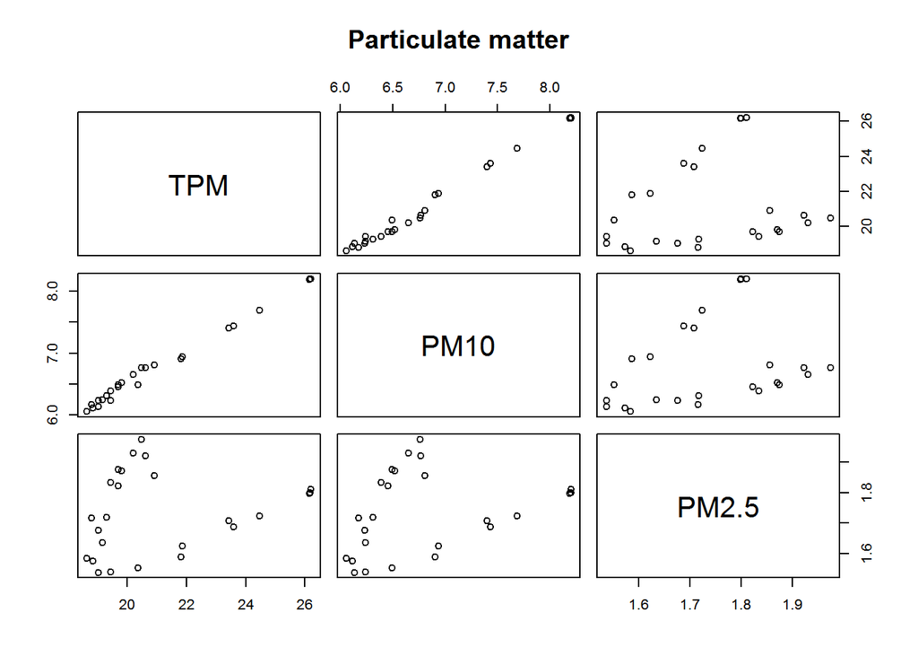

Using Pearson’s product moment correlation to calculate the correlations between TPM, PM10, and PM2.5 we see that the correlation between TPM and PM10 is the strongest.

```
##
##  Pearson's product-moment correlation
##
## data:  summed.can$TPM and summed.can$PM10
## t = 46.941, df = 23, p-value < 2.2e-16
## alternative hypothesis: true correlation is not equal to 0
## 95 percent confidence interval:
##  0.9880960 0.9977515
## sample estimates:
##       cor
## 0.9948215
```

```
##
##  Pearson's product-moment correlation
##
## data:  summed.can$PM10 and summed.can$PM2.5
## t = 1.4563, df = 23, p-value = 0.1588
## alternative hypothesis: true correlation is not equal to 0
## 95 percent confidence interval:
##  -0.1181335  0.6150748
## sample estimates:
##       cor
## 0.2905602
```

```
##
##  Pearson's product-moment correlation
##
## data:  summed.can$TPM and summed.can$PM2.5
## t = 0.94093, df = 23, p-value = 0.3565
## alternative hypothesis: true correlation is not equal to 0
## 95 percent confidence interval:
##  -0.2192852  0.5461136
## sample estimates:
##       cor
## 0.1925275
```

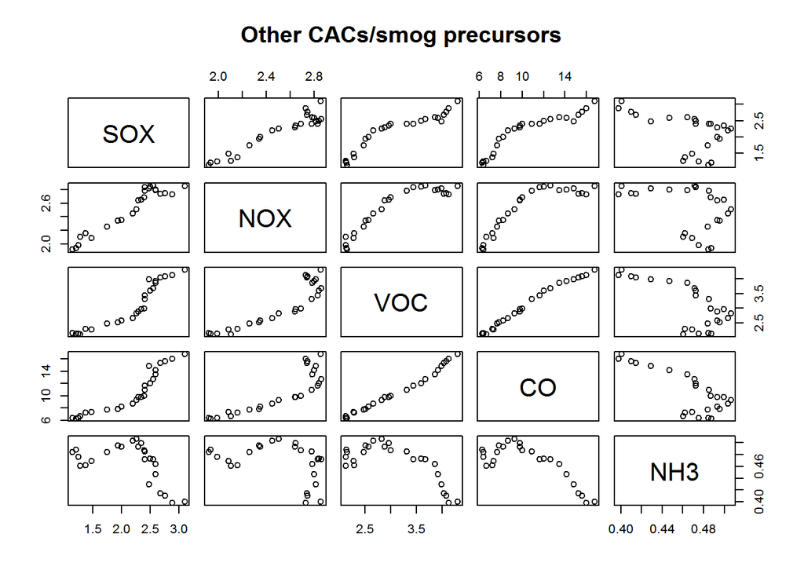

Most of the other CACs: SOx, NOx, VOC, and CO all seem to be correlated, although the correlation between VOC and CO is the strongest. Ammonia emissions (NH3) do not seem to be correlated with any of the smog precursor pollutants.

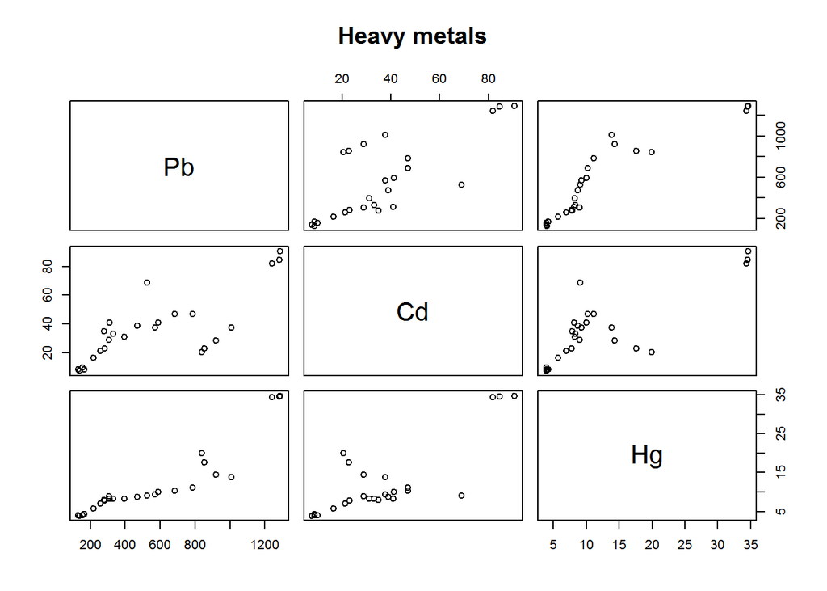

The heavy metals seem to have some correlation but not any strong correlations.

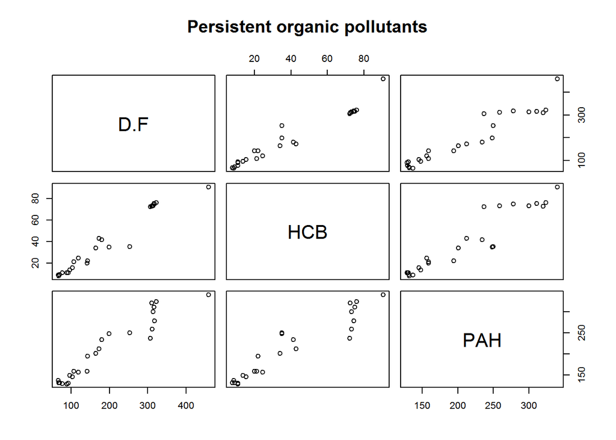

# Bivariate Analysis

### Talk about some of the relationships you observed in this part of the investigation. How did the feature(s) of interest vary with other features in the dataset?

In general, all 14 pollutants have decreased over the last 25 years except for particulate matter and ammonia. There was a significant increase in Cd from around 1993 to 2002. I will investigate these four pollutants further in the multivariate analysis portion.

### Did you observe any interesting relationships between the other features (not the main feature(s) of interest)?

I just looked at the contributing sources for the four pollutants (TPM, PM10, PM2.5, and NH3) that have increased over time. I only plotted the distributions for 1990 and 2014 and it appears that the distribution between sources didn’t change much over time. Open sources are by far the most significant contributing source for particulate matter pollutants as well as ammonia.

### What was the strongest relationship you found?

The correlation between TPM and PM10 was strongest with Pearson’s product-moment correlation of 0.99.

# Multivariate Plots Section

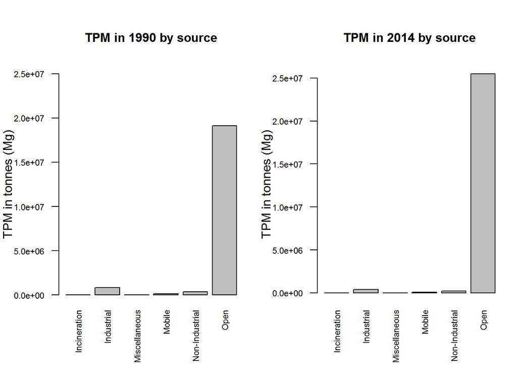

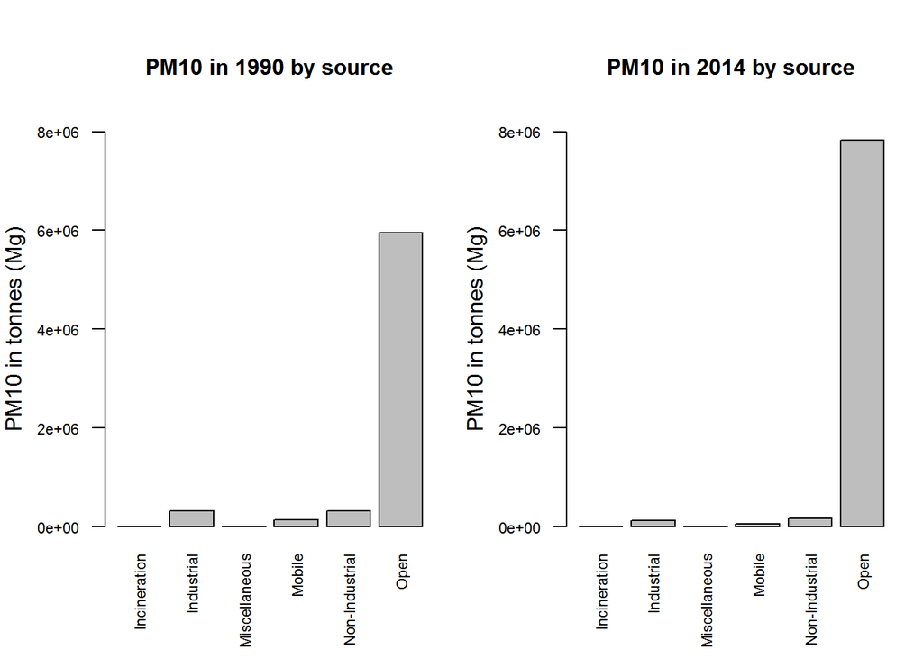

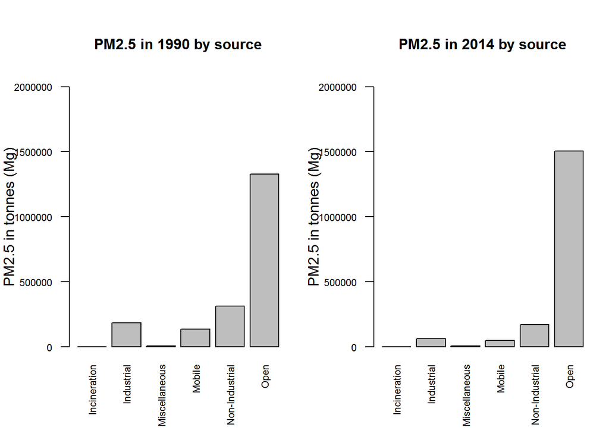

Almost all particulate matter emissions come from open sources and this distribution does not seem to have varied greatly between 1990 and 2014. Some other sectors do not have insignificant contributions to PM2.5, but this may be because the values are much smaller overall. I will examine only open source emissions of PM more closely.

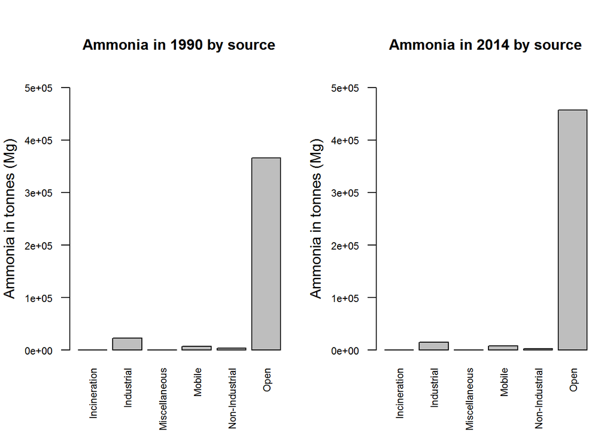

Most ammonia emissions also seem to come from open sources. The distribution amongst sources does not seem to have changed between 1990 and 2014.

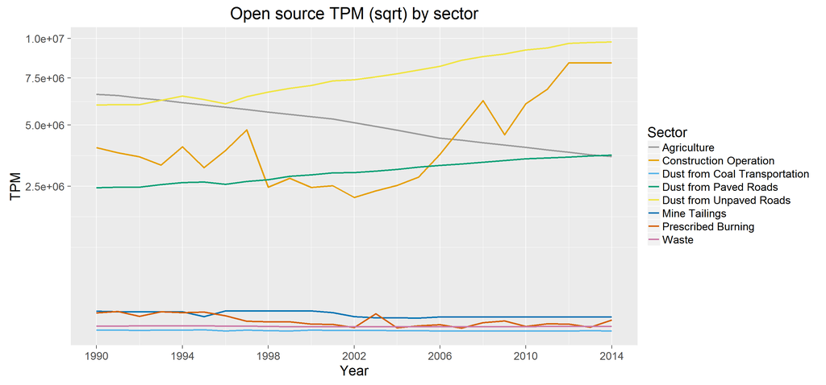

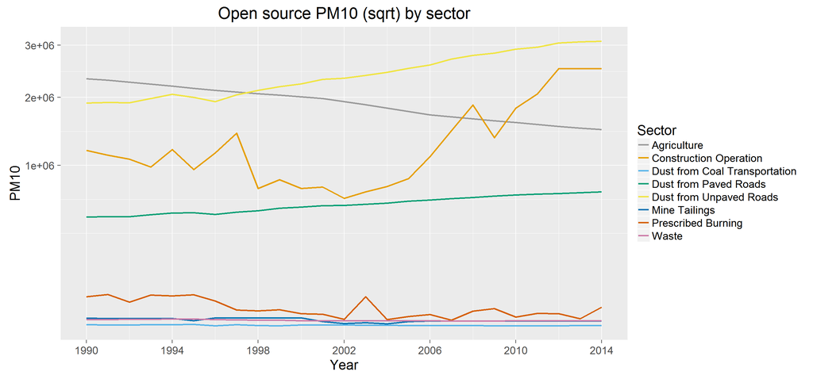

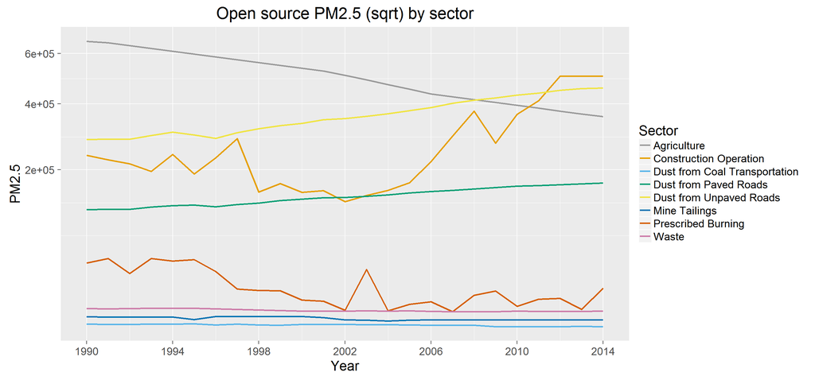

The increase in emissions from 2005 to 2014 is driven by emissions from construction operations, combined with the steady increase in dust from roads since the mid-1990s. However, these increases are offset by consistent emission decreases throughout the time series from agriculture, prescribed burning,and other sectors.

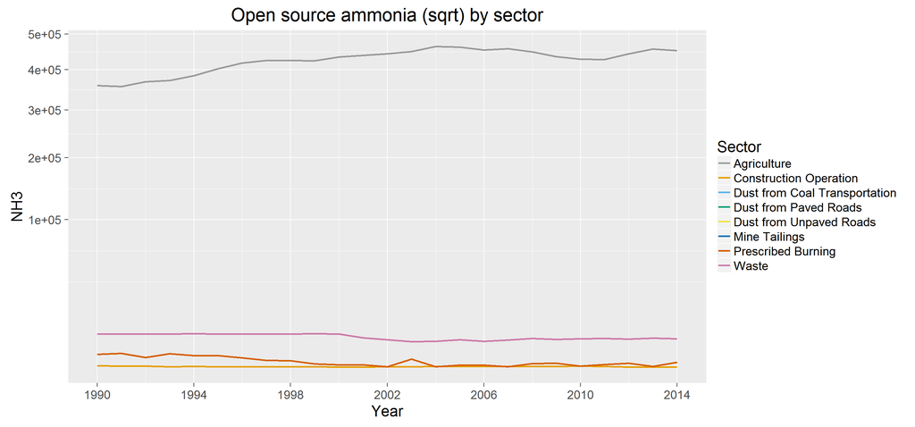

The increasing trend in NH3 emissions appears to be almost entirely driven by the agricultural sector. Primary sources of NH3 in agriculture are from animal production and fertilizer.